# AudioFilteringGR

This notebook details the Model Creation for MSOE Applied ML Final Project pretaining to filtering noise from audio data. This notebook details the model creation and iteration process for 1-Dimensional U-Net models.

```python
# from pydub import AudioSegment
import os
import pydot
import tensorflow as tf
import os
import glob
import math
import random
import numpy as np
import matplotlib.pyplot as plt
from PIL import Image
from scipy.io import wavfile
from IPython.display import Audio
from tensorflow.keras import backend as K
from tensorflow import keras
from tensorflow.keras.layers import Conv1D,Conv1DTranspose,Concatenate,Input
import numpy as np
import IPython.display
import glob
from tqdm.notebook import tqdm
# import librosa.display
import matplotlib.pyplot as plt
```

```python
rate = 16000
```

```python
 tf.config.list_physical_devices('GPU')
```

```
[PhysicalDevice(name='/physical_device:GPU:0', device_type='GPU')]
```

```python
# Function to read WAV files and create datasets
def create_dataset(clean_paths, noisy_paths, batch_size=64, shuffle=True, audio_length=16000):
#     def load_wav(file_path):
#         # Read in a file
#         audio = tf.io.read_file(file_path)
#         # Decode to tensor
#         audio, _ = tf.audio.decode_wav(audio, desired_channels=1)
#         # Make it mono
#         audio = tf.squeeze(audio, axis=-1)
#         # Pad it to 16128
#         # For some reason this step needs to be VERY explicit
#         audio = tf.pad(audio, paddings=[[0, audio_length - tf.shape(audio)[0]]], mode='CONSTANT', constant_values=0)
#         return audio
    def load_wav(file_path):
        # Read in a file
        audio = tf.io.read_file(file_path)
        # Decode to tensor
        audio, _ = tf.audio.decode_wav(audio, desired_channels=1)
        # Make it mono
        audio = tf.squeeze(audio, axis=-1)
        # Pad or truncate it to 16000
        audio = tf.cond(tf.shape(audio)[0] < audio_length,
                        # If less than 16000 pad to 16000
                        lambda: tf.pad(audio, paddings=[[0, audio_length - tf.shape(audio)[0]]], mode='CONSTANT', constant_values=0),
                        # If more than 16000 truncate the dead space
                        lambda: audio[:audio_length])
        return audio

    # Get a list of paths pointing to individual samples wav files
    clean_dataset = tf.data.Dataset.from_tensor_slices(clean_paths)
    # replace those paths with the audio actually stored there
    clean_dataset = clean_dataset.map(load_wav)
    # Get a list of paths pointing to individual samples wav files
    noisy_dataset = tf.data.Dataset.from_tensor_slices(noisy_paths)
    # replace those paths with the audio actually stored there
    noisy_dataset = noisy_dataset.map(load_wav)
    # Zip the clean and noisy datasets together
    dataset = tf.data.Dataset.zip((noisy_dataset, clean_dataset))
    # Shuffly the data so all the same samples arent stuck together
    if shuffle:
        dataset = dataset.shuffle(100)
    # Batch the data and drop the remainders so every batch is the same
    dataset = dataset.batch(batch_size, drop_remainder=True)
    return dataset

# Function to get the length of audio files
def get_audio_length(paths):
    audio_lengths = []
    for path in tqdm(paths):
        audio = tf.io.read_file(path)
        audio, _ = tf.audio.decode_wav(audio, desired_channels=1)
        audio_lengths.append(audio.shape[0])
    return audio_lengths
# Paths to train and test folders
train_clean_paths = glob.glob('WavesFromSpecs/y_train/*.wav')
train_noisy_paths = glob.glob('WavesFromSpecs/train/*.wav')
test_clean_paths = glob.glob('WavesFromSpecs/y_test/*.wav')
test_noisy_paths = glob.glob('WavesFromSpecs/test/*.wav')


# Create train and test datasets
train_dataset = create_dataset(train_clean_paths, train_noisy_paths, batch_size=16, audio_length=rate) # 16 one second sample batches
test_dataset = create_dataset(test_clean_paths, test_noisy_paths, batch_size=16, audio_length=rate) # 16 one second sample batches
```

```
2024-05-01 16:37:29.572585: I tensorflow/core/common_runtime/gpu/gpu_device.cc:1638] Created device /job:localhost/replica:0/task:0/device:GPU:0 with 13797 MB memory:  -> device: 0, name: Tesla T4, pci bus id: 0000:60:00.0, compute capability: 7.5
```

```python
audio, sample_rate = tf.audio.decode_wav(tf.io.read_file("WavesFromSpecs/test/1081-125237-0053.wav"))

print("Sample Rate:", sample_rate)
print("Audio Shape:", audio.shape)
```

```
Sample Rate: tf.Tensor(16000, shape=(), dtype=int32)
Audio Shape: (16128, 1)
```

```python
# # Print audio lengths
# print("Train Clean Audio Lengths:", get_audio_length(train_clean_paths))
# print("Train Noisy Audio Lengths:", get_audio_length(train_noisy_paths))
# print("Test Clean Audio Lengths:", get_audio_length(test_clean_paths))
print("Test Noisy Audio Lengths:", get_audio_length(test_noisy_paths))
```

[output not shown]

# Create the Base Model

```python
# Define the model
batching_size = rate
inp = Input(shape=(batching_size, 1))
c1 = Conv1D(2, 32, 2, 'same', activation='relu')(inp)
c2 = Conv1D(4, 32, 2, 'same', activation='relu')(c1)
c3 = Conv1D(8, 32, 2, 'same', activation='relu')(c2)
c4 = Conv1D(16, 32, 2, 'same', activation='relu')(c3)
c5 = Conv1D(32, 32, 2, 'same', activation='relu')(c4)

dc1 = Conv1DTranspose(32, 32, 1, padding='same')(c5)
conc = Concatenate()([c5, dc1])
dc2 = Conv1DTranspose(16, 32, 2, padding='same')(conc)
conc = Concatenate()([c4, dc2])
dc3 = Conv1DTranspose(8, 32, 2, padding='same')(conc)
conc = Concatenate()([c3, dc3])
dc4 = Conv1DTranspose(4, 32, 2, padding='same')(conc)
conc = Concatenate()([c2, dc4])
dc5 = Conv1DTranspose(2, 32, 2, padding='same')(conc)
conc = Concatenate()([c1, dc5])
dc6 = Conv1DTranspose(1, 32, 2, padding='same')(conc)
conc = Concatenate()([inp, dc6])
dc7 = Conv1DTranspose(1, 32, 1, padding='same', activation='linear')(conc)

model = tf.keras.models.Model(inp, dc7)
model.summary()
```

```
Model: "model_2"
__________________________________________________________________________________________________
 Layer (type)                   Output Shape         Param #     Connected to
==================================================================================================
 input_3 (InputLayer)           [(None, 16000, 1)]   0           []

 conv1d_10 (Conv1D)             (None, 8000, 2)      66          ['input_3[0][0]']

 conv1d_11 (Conv1D)             (None, 4000, 4)      260         ['conv1d_10[0][0]']

 conv1d_12 (Conv1D)             (None, 2000, 8)      1032        ['conv1d_11[0][0]']

 conv1d_13 (Conv1D)             (None, 1000, 16)     4112        ['conv1d_12[0][0]']

 conv1d_14 (Conv1D)             (None, 500, 32)      16416       ['conv1d_13[0][0]']

 conv1d_transpose_14 (Conv1DTra  (None, 500, 32)     32800       ['conv1d_14[0][0]']
 nspose)

 concatenate_12 (Concatenate)   (None, 500, 64)      0           ['conv1d_14[0][0]',
                                                                  'conv1d_transpose_14[0][0]']

 conv1d_transpose_15 (Conv1DTra  (None, 1000, 16)    32784       ['concatenate_12[0][0]']
 nspose)

 concatenate_13 (Concatenate)   (None, 1000, 32)     0           ['conv1d_13[0][0]',
                                                                  'conv1d_transpose_15[0][0]']

 conv1d_transpose_16 (Conv1DTra  (None, 2000, 8)     8200        ['concatenate_13[0][0]']
 nspose)

 concatenate_14 (Concatenate)   (None, 2000, 16)     0           ['conv1d_12[0][0]',
                                                                  'conv1d_transpose_16[0][0]']

 conv1d_transpose_17 (Conv1DTra  (None, 4000, 4)     2052        ['concatenate_14[0][0]']
 nspose)

 concatenate_15 (Concatenate)   (None, 4000, 8)      0           ['conv1d_11[0][0]',
                                                                  'conv1d_transpose_17[0][0]']

 conv1d_transpose_18 (Conv1DTra  (None, 8000, 2)     514         ['concatenate_15[0][0]']
 nspose)

 concatenate_16 (Concatenate)   (None, 8000, 4)      0           ['conv1d_10[0][0]',
                                                                  'conv1d_transpose_18[0][0]']

 conv1d_transpose_19 (Conv1DTra  (None, 16000, 1)    129         ['concatenate_16[0][0]']
 nspose)

 concatenate_17 (Concatenate)   (None, 16000, 2)     0           ['input_3[0][0]',
                                                                  'conv1d_transpose_19[0][0]']

 conv1d_transpose_20 (Conv1DTra  (None, 16000, 1)    65          ['concatenate_17[0][0]']
 nspose)

==================================================================================================
Total params: 98,430
Trainable params: 98,430
Non-trainable params: 0
__________________________________________________________________________________________________
```

```python
# tf.keras.utils.plot_model(model,show_shapes=True,show_layer_names=False)
```

# Train the Base model:

Train the model three times saving each one so we can average the metrics. Due to memory contrainsts this model may be commented out for the final print but it was used to generate the base models.

```python
# for i in range(3):
#     # Define the model
#     file_length = rate
#     batch_size = 16
#     filterX =1
#     # input_size1d = (1,16128)
#     input_size1d = (rate,1)
#     inp = Input(shape=(input_size1d))
#     c1 = Conv1D(2*filterX, 32, 2, 'same', activation='relu')(inp)
#     c2 = Conv1D(4*filterX, 32, 2, 'same', activation='relu')(c1)
#     c3 = Conv1D(8*filterX, 32, 2, 'same', activation='relu')(c2)
#     c4 = Conv1D(16*filterX, 32, 2, 'same', activation='relu')(c3)
#     c5 = Conv1D(32*filterX, 32, 2, 'same', activation='relu')(c4)

#     dc1 = Conv1DTranspose(32*filterX, 32, 1, padding='same')(c5)
#     conc = Concatenate()([c5, dc1])
#     dc2 = Conv1DTranspose(16*filterX, 32, 2, padding='same')(conc)
#     conc = Concatenate()([c4, dc2])
#     dc3 = Conv1DTranspose(8*filterX, 32, 2, padding='same')(conc)
#     conc = Concatenate()([c3, dc3])
#     dc4 = Conv1DTranspose(4*filterX, 32, 2, padding='same')(conc)
#     conc = Concatenate()([c2, dc4])
#     dc5 = Conv1DTranspose(2*filterX, 32, 2, padding='same')(conc)
#     conc = Concatenate()([c1, dc5])
#     dc6 = Conv1DTranspose(1*filterX, 32, 2, padding='same')(conc)
#     conc = Concatenate()([inp, dc6])
#     dc7 = Conv1DTranspose(1, 32, 1, padding='same', activation='linear')(conc)

#     un_1d_base = tf.keras.models.Model(inp, dc7)
#     # un_1d_base.compile(optimizer=tf.keras.optimizers.Adam(0.002),loss='mse',metrics=['mae','accuracy']
#     un_1d_base.compile(optimizer=tf.keras.optimizers.Adam(0.001),loss='mse',metrics=['mae','accuracy'])
#     historybase = un_1d_base.fit(train_dataset,epochs=20)
#     un_1d_base.save(f"un_1d_base{i}.keras")
#     K.clear_session()
```

# 5X Filters Model

Create a model with 5 Times the number of filters to test if the models performance is being constrained by a lack of dimensionality from filters.

```python
input_size1d = (rate,1)
inp = Input(shape=(input_size1d))
filterX =5
c1 = Conv1D(2*filterX, 32, 2, 'same', activation='relu')(inp)
c2 = Conv1D(4*filterX, 32, 2, 'same', activation='relu')(c1)
c3 = Conv1D(8*filterX, 32, 2, 'same', activation='relu')(c2)
c4 = Conv1D(16*filterX, 32, 2, 'same', activation='relu')(c3)
c5 = Conv1D(32*filterX, 32, 2, 'same', activation='relu')(c4)

dc1 = Conv1DTranspose(32*filterX, 32, 1, padding='same')(c5)
conc = Concatenate()([c5, dc1])
dc2 = Conv1DTranspose(16*filterX, 32, 2, padding='same')(conc)
conc = Concatenate()([c4, dc2])
dc3 = Conv1DTranspose(8*filterX, 32, 2, padding='same')(conc)
conc = Concatenate()([c3, dc3])
dc4 = Conv1DTranspose(4*filterX, 32, 2, padding='same')(conc)
conc = Concatenate()([c2, dc4])
dc5 = Conv1DTranspose(2*filterX, 32, 2, padding='same')(conc)
conc = Concatenate()([c1, dc5])
dc6 = Conv1DTranspose(1*filterX, 32, 2, padding='same')(conc)
conc = Concatenate()([inp, dc6])
dc7 = Conv1DTranspose(1, 32, 1, padding='same', activation='linear')(conc)

un_1d_big = tf.keras.models.Model(inp, dc7)
un_1d_big.summary()
```

```
Model: "model_1"
__________________________________________________________________________________________________
 Layer (type)                   Output Shape         Param #     Connected to
==================================================================================================
 input_2 (InputLayer)           [(None, 16000, 1)]   0           []

 conv1d_5 (Conv1D)              (None, 8000, 10)     330         ['input_2[0][0]']

 conv1d_6 (Conv1D)              (None, 4000, 20)     6420        ['conv1d_5[0][0]']

 conv1d_7 (Conv1D)              (None, 2000, 40)     25640       ['conv1d_6[0][0]']

 conv1d_8 (Conv1D)              (None, 1000, 80)     102480      ['conv1d_7[0][0]']

 conv1d_9 (Conv1D)              (None, 500, 160)     409760      ['conv1d_8[0][0]']

 conv1d_transpose_7 (Conv1DTran  (None, 500, 160)    819360      ['conv1d_9[0][0]']
 spose)

 concatenate_6 (Concatenate)    (None, 500, 320)     0           ['conv1d_9[0][0]',
                                                                  'conv1d_transpose_7[0][0]']

 conv1d_transpose_8 (Conv1DTran  (None, 1000, 80)    819280      ['concatenate_6[0][0]']
 spose)

 concatenate_7 (Concatenate)    (None, 1000, 160)    0           ['conv1d_8[0][0]',
                                                                  'conv1d_transpose_8[0][0]']

 conv1d_transpose_9 (Conv1DTran  (None, 2000, 40)    204840      ['concatenate_7[0][0]']
 spose)

 concatenate_8 (Concatenate)    (None, 2000, 80)     0           ['conv1d_7[0][0]',
                                                                  'conv1d_transpose_9[0][0]']

 conv1d_transpose_10 (Conv1DTra  (None, 4000, 20)    51220       ['concatenate_8[0][0]']
 nspose)

 concatenate_9 (Concatenate)    (None, 4000, 40)     0           ['conv1d_6[0][0]',
                                                                  'conv1d_transpose_10[0][0]']

 conv1d_transpose_11 (Conv1DTra  (None, 8000, 10)    12810       ['concatenate_9[0][0]']
 nspose)

 concatenate_10 (Concatenate)   (None, 8000, 20)     0           ['conv1d_5[0][0]',
                                                                  'conv1d_transpose_11[0][0]']

 conv1d_transpose_12 (Conv1DTra  (None, 16000, 5)    3205        ['concatenate_10[0][0]']
 nspose)

 concatenate_11 (Concatenate)   (None, 16000, 6)     0           ['input_2[0][0]',
                                                                  'conv1d_transpose_12[0][0]']

 conv1d_transpose_13 (Conv1DTra  (None, 16000, 1)    193         ['concatenate_11[0][0]']
 nspose)

==================================================================================================
Total params: 2,455,538
Trainable params: 2,455,538
Non-trainable params: 0
__________________________________________________________________________________________________
```

# Train the 5X Filters model

Train the model three times saving each one so we can average the metrics. Due to memory contrainsts this model may be commented out for the final print but it was used to generate the 5X Filters models.

```python
# for i in range(3):
#     # Define the model
#     file_length = rate
#     batch_size = 16
#     filterX =5
#     # input_size1d = (1,16128)
#     input_size1d = (rate,1)
#     inp = Input(shape=(input_size1d))
#     c1 = Conv1D(2*filterX, 32, 2, 'same', activation='relu')(inp)
#     c2 = Conv1D(4*filterX, 32, 2, 'same', activation='relu')(c1)
#     c3 = Conv1D(8*filterX, 32, 2, 'same', activation='relu')(c2)
#     c4 = Conv1D(16*filterX, 32, 2, 'same', activation='relu')(c3)
#     c5 = Conv1D(32*filterX, 32, 2, 'same', activation='relu')(c4)

#     dc1 = Conv1DTranspose(32*filterX, 32, 1, padding='same')(c5)
#     conc = Concatenate()([c5, dc1])
#     dc2 = Conv1DTranspose(16*filterX, 32, 2, padding='same')(conc)
#     conc = Concatenate()([c4, dc2])
#     dc3 = Conv1DTranspose(8*filterX, 32, 2, padding='same')(conc)
#     conc = Concatenate()([c3, dc3])
#     dc4 = Conv1DTranspose(4*filterX, 32, 2, padding='same')(conc)
#     conc = Concatenate()([c2, dc4])
#     dc5 = Conv1DTranspose(2*filterX, 32, 2, padding='same')(conc)
#     conc = Concatenate()([c1, dc5])
#     dc6 = Conv1DTranspose(1*filterX, 32, 2, padding='same')(conc)
#     conc = Concatenate()([inp, dc6])
#     dc7 = Conv1DTranspose(1, 32, 1, padding='same', activation='linear')(conc)

#     un_1d_big = tf.keras.models.Model(inp, dc7)
#     # un_1d_base.compile(optimizer=tf.keras.optimizers.Adam(0.002),loss='mse',metrics=['mae','accuracy']
#     un_1d_big.compile(optimizer=tf.keras.optimizers.Adam(0.001),loss='mse',metrics=['mae','accuracy'])
#     historybig = un_1d_big.fit(train_dataset,epochs=20)
#     un_1d_big.save(f"un_1d_big{i}.keras")
#     K.clear_session()
```

[output not shown]

# 0.5X Filters Model

Create a model with half the filters of the Base model to test whether the model benefits from a restricted feature space.

```python
filterX =0.5
# input_size1d = (1,16128)
input_size1d = (rate,1)
inp = Input(shape=(input_size1d))
c1 = Conv1D(2*filterX, 32, 2, 'same', activation='relu')(inp)
c2 = Conv1D(4*filterX, 32, 2, 'same', activation='relu')(c1)
c3 = Conv1D(8*filterX, 32, 2, 'same', activation='relu')(c2)
c4 = Conv1D(16*filterX, 32, 2, 'same', activation='relu')(c3)
c5 = Conv1D(32*filterX, 32, 2, 'same', activation='relu')(c4)

dc1 = Conv1DTranspose(32*filterX, 32, 1, padding='same')(c5)
conc = Concatenate()([c5, dc1])
dc2 = Conv1DTranspose(16*filterX, 32, 2, padding='same')(conc)
conc = Concatenate()([c4, dc2])
dc3 = Conv1DTranspose(8*filterX, 32, 2, padding='same')(conc)
conc = Concatenate()([c3, dc3])
dc4 = Conv1DTranspose(4*filterX, 32, 2, padding='same')(conc)
conc = Concatenate()([c2, dc4])
dc5 = Conv1DTranspose(2*filterX, 32, 2, padding='same')(conc)
conc = Concatenate()([c1, dc5])
dc6 = Conv1DTranspose(1, 32, 2, padding='same')(conc)
conc = Concatenate()([inp, dc6])
dc7 = Conv1DTranspose(1, 32, 1, padding='same', activation='linear')(conc)

un_1d_small = tf.keras.models.Model(inp, dc7)
un_1d_small.summary()
```

```
Model: "model"
__________________________________________________________________________________________________
 Layer (type)                   Output Shape         Param #     Connected to
==================================================================================================
 input_1 (InputLayer)           [(None, 16000, 1)]   0           []

 conv1d (Conv1D)                (None, 8000, 1)      33          ['input_1[0][0]']

 conv1d_1 (Conv1D)              (None, 4000, 2)      66          ['conv1d[0][0]']

 conv1d_2 (Conv1D)              (None, 2000, 4)      260         ['conv1d_1[0][0]']

 conv1d_3 (Conv1D)              (None, 1000, 8)      1032        ['conv1d_2[0][0]']

 conv1d_4 (Conv1D)              (None, 500, 16)      4112        ['conv1d_3[0][0]']

 conv1d_transpose (Conv1DTransp  (None, 500, 16)     8208        ['conv1d_4[0][0]']
 ose)

 concatenate (Concatenate)      (None, 500, 32)      0           ['conv1d_4[0][0]',
                                                                  'conv1d_transpose[0][0]']

 conv1d_transpose_1 (Conv1DTran  (None, 1000, 8)     8200        ['concatenate[0][0]']
 spose)

 concatenate_1 (Concatenate)    (None, 1000, 16)     0           ['conv1d_3[0][0]',
                                                                  'conv1d_transpose_1[0][0]']

 conv1d_transpose_2 (Conv1DTran  (None, 2000, 4)     2052        ['concatenate_1[0][0]']
 spose)

 concatenate_2 (Concatenate)    (None, 2000, 8)      0           ['conv1d_2[0][0]',
                                                                  'conv1d_transpose_2[0][0]']

 conv1d_transpose_3 (Conv1DTran  (None, 4000, 2)     514         ['concatenate_2[0][0]']
 spose)

 concatenate_3 (Concatenate)    (None, 4000, 4)      0           ['conv1d_1[0][0]',
                                                                  'conv1d_transpose_3[0][0]']

 conv1d_transpose_4 (Conv1DTran  (None, 8000, 1)     129         ['concatenate_3[0][0]']
 spose)

 concatenate_4 (Concatenate)    (None, 8000, 2)      0           ['conv1d[0][0]',
                                                                  'conv1d_transpose_4[0][0]']

 conv1d_transpose_5 (Conv1DTran  (None, 16000, 1)    65          ['concatenate_4[0][0]']
 spose)

 concatenate_5 (Concatenate)    (None, 16000, 2)     0           ['input_1[0][0]',
                                                                  'conv1d_transpose_5[0][0]']

 conv1d_transpose_6 (Conv1DTran  (None, 16000, 1)    65          ['concatenate_5[0][0]']
 spose)

==================================================================================================
Total params: 24,736
Trainable params: 24,736
Non-trainable params: 0
__________________________________________________________________________________________________
```

# Train the 0.5X Filters model

Train the model three times saving each one so we can average the metrics. Due to memory contraints this model may be commented out for the final print but it was used to generate the 0.5X Filters models.

```python
for i in range(3):
    # Define the model
    file_length = rate
    batch_size = 16
    filterX =0.5
    # input_size1d = (1,16128)
    input_size1d = (rate,1)
    inp = Input(shape=(input_size1d))
    c1 = Conv1D(2*filterX, 32, 2, 'same', activation='relu')(inp)
    c2 = Conv1D(4*filterX, 32, 2, 'same', activation='relu')(c1)
    c3 = Conv1D(8*filterX, 32, 2, 'same', activation='relu')(c2)
    c4 = Conv1D(16*filterX, 32, 2, 'same', activation='relu')(c3)
    c5 = Conv1D(32*filterX, 32, 2, 'same', activation='relu')(c4)

    dc1 = Conv1DTranspose(32*filterX, 32, 1, padding='same')(c5)
    conc = Concatenate()([c5, dc1])
    dc2 = Conv1DTranspose(16*filterX, 32, 2, padding='same')(conc)
    conc = Concatenate()([c4, dc2])
    dc3 = Conv1DTranspose(8*filterX, 32, 2, padding='same')(conc)
    conc = Concatenate()([c3, dc3])
    dc4 = Conv1DTranspose(4*filterX, 32, 2, padding='same')(conc)
    conc = Concatenate()([c2, dc4])
    dc5 = Conv1DTranspose(2*filterX, 32, 2, padding='same')(conc)
    conc = Concatenate()([c1, dc5])
    dc6 = Conv1DTranspose(1, 32, 2, padding='same')(conc)
    conc = Concatenate()([inp, dc6])
    dc7 = Conv1DTranspose(1, 32, 1, padding='same', activation='linear')(conc)

    un_1d_small = tf.keras.models.Model(inp, dc7)
    # un_1d_base.compile(optimizer=tf.keras.optimizers.Adam(0.002),loss='mse',metrics=['mae','accuracy']
    un_1d_small.compile(optimizer=tf.keras.optimizers.Adam(0.001),loss='mse',metrics=['mae','accuracy'])
    historysmall = un_1d_small.fit(train_dataset,epochs=20)
    un_1d_small.save(f"un_1d_small{i}.keras")
    K.clear_session()
```

```python
# audio_length=rate
# def load_wav(file_path):
#     # Read in a file
#     audio = tf.io.read_file(file_path)
#     # Decode to tensor
#     audio, _ = tf.audio.decode_wav(audio, desired_channels=1)
#     # Make it mono
#     audio = tf.squeeze(audio, axis=-1)
#     # Pad it to 16128
#     # For some reason this step needs to be VERY explicit
#     audio = tf.pad(audio, paddings=[[0, audio_length - tf.shape(audio)[0]]], mode='CONSTANT', constant_values=0)
#     return audio
```

# Lets Generate Plots for the First Three Models

Note that big and base models are loaded from a folder called "FinalModels" this was done so that the notebook could reference static models between session instead of making new models everytime this notebook was worked on and to work around memory contraints that prevent training all the models in one go. This folder is not created in this notebook and must be added manually. Models were generated using this notebook and then moved in there manually.

```
2024-05-09 00:27:19.065138: I tensorflow/compiler/xla/stream_executor/cuda/cuda_dnn.cc:424] Loaded cuDNN version 8901
```

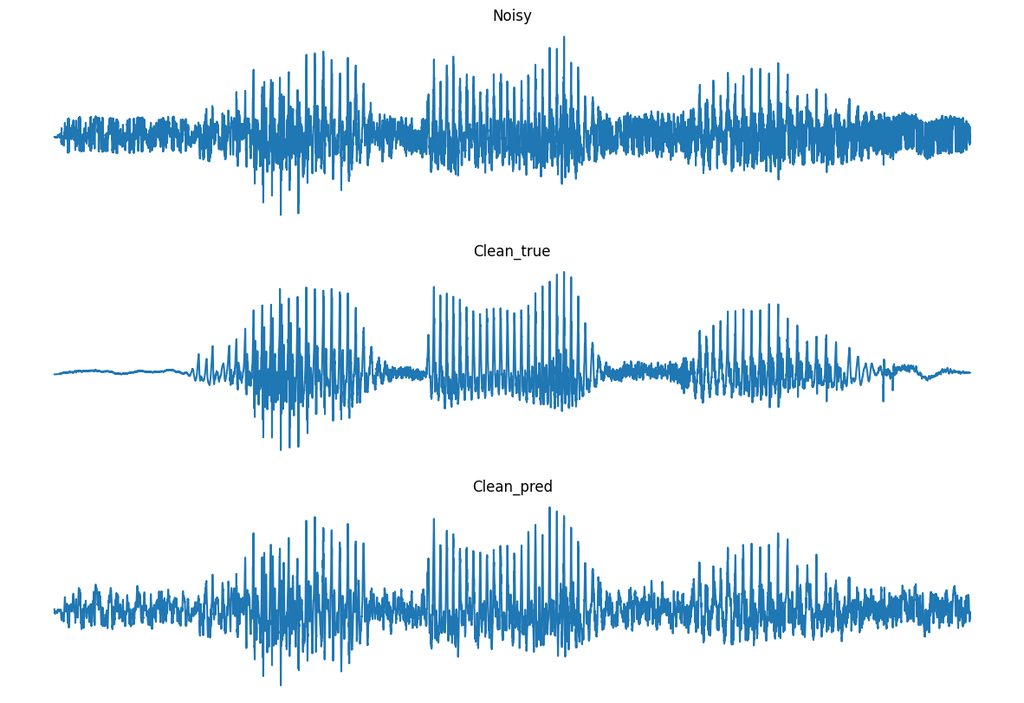

```python
%matplotlib inline
def load_wav(file_path):
    audio_length = 16000
    # Read in a file
    audio = tf.io.read_file(file_path)
    # Decode to tensor
    audio, _ = tf.audio.decode_wav(audio, desired_channels=1)
    # Make it mono
    audio = tf.squeeze(audio, axis=-1)
    # Pad or truncate it to 16000
    audio = tf.cond(tf.shape(audio)[0] < audio_length,
                    # If less than 16000 pad to 16000
                    lambda: tf.pad(audio, paddings=[[0, audio_length - tf.shape(audio)[0]]], mode='CONSTANT', constant_values=0),
                    # If more than 16000 truncate the dead space
                    lambda: audio[:audio_length])
    return audio
n = 2
y = load_wav("WavesFromSpecs/y_test/1034-121119-0049.wav")
X = load_wav("WavesFromSpecs/test/1034-121119-0049.wav")

# NOTE: COMMENT THIS MODEL LOADING PORTION OUT IF YOU CAN RUN THE ENTIRE NOTEBOOK WITHOUT MEMORY ISSUES
# Loading due to memory contraints preventing training.
un_1d_small = keras.models.load_model("FinalModels/un_1d_small2.keras")
un_1d_base = keras.models.load_model("FinalModels/un_1d_base2.keras")
un_1d_big = keras.models.load_model("FinalModels/un_1d_big2.keras")


pred = un_1d_small.predict(tf.expand_dims(X, axis=0))
fig, axes = plt.subplots(3, 1, figsize=(15,10),sharex=True)
axes[0].plot(X)
axes[0].set_axis_off()
axes[0].set_title('Noisy')
axes[1].plot(y)
axes[1].set_axis_off()
axes[1].set_title('Clean_true')
axes[2].plot(pred[0])
axes[2].set_axis_off()
axes[2].set_title('Clean_pred')
plt.show()
```

```python
FFT_LENGTH = 512
WINDOW_LENGTH = 512
WINDOW_STEP = int(WINDOW_LENGTH / 2)
phaseMax = 3.141592653589793
phaseMin = -3.141592653589793
magnitudeMax = 2211683.973249525
magnitudeMin = 0.0
rate = 16000

def amplifyMagnitudeByLog(d):
    return 188.301 * math.log10(d + 1)

def weakenAmplifiedMagnitude(d):
    return math.pow(10, d/188.301)-1

def generateLinearScale(magnitudePixels, phasePixels, magnitudeMin, magnitudeMax, phaseMin, phaseMax):
    height = magnitudePixels.shape[0]
    width = magnitudePixels.shape[1]
    magnitudeRange = magnitudeMax - magnitudeMin
    phaseRange = phaseMax - phaseMin
    rgbArray = np.zeros((height, width, 3), 'uint8')

    for w in range(width):
        for h in range(height):
            magnitudePixels[h,w] = (magnitudePixels[h,w] - magnitudeMin) / (magnitudeRange) * 255 * 2
            magnitudePixels[h,w] = amplifyMagnitudeByLog(magnitudePixels[h,w])
            phasePixels[h,w] = (phasePixels[h,w] - phaseMin) / (phaseRange) * 255
            red = 255 if magnitudePixels[h,w] > 255 else magnitudePixels[h,w]
            green = (magnitudePixels[h,w] - 255) if magnitudePixels[h,w] > 255 else 0
            blue = phasePixels[h,w]
            rgbArray[h,w,0] = int(red)
            rgbArray[h,w,1] = int(green)
            rgbArray[h,w,2] = int(blue)
    return rgbArray

def recoverLinearScale(rgbArray, magnitudeMin, magnitudeMax, phaseMin, phaseMax):
    width = rgbArray.shape[1]
    height = rgbArray.shape[0]
    print(phaseMax,phaseMin)
    magnitudeVals = rgbArray[:,:,0].astype(float) + rgbArray[:,:,1].astype(float)
    phaseVals = rgbArray[:,:,2].astype(float)
    phaseRange = phaseMax - phaseMin
    magnitudeRange = magnitudeMax - magnitudeMin

    for w in range(width):
        for h in range(height):
            phaseVals[h,w] = (phaseVals[h,w] / 255 * phaseRange) + phaseMin
            magnitudeVals[h,w] = weakenAmplifiedMagnitude(magnitudeVals[h,w])
            magnitudeVals[h,w] = (magnitudeVals[h,w] / (255*2) * magnitudeRange) + magnitudeMin
    return magnitudeVals, phaseVals
def generateSpectrogramForWave(signal):
    global magnitudeMin
    global magnitudeMax
    global phaseMin
    global phaseMax
    buffer = np.zeros(int(signal.size + WINDOW_STEP - (signal.size % WINDOW_STEP)))
    buffer[0:len(signal)] = signal
    height = int(FFT_LENGTH / 2 + 1)
    width = int(len(buffer) / (WINDOW_STEP) - 1)
    magnitudePixels = np.zeros((height, width))
    phasePixels = np.zeros((height, width))

    for w in range(width):
        buff = np.zeros(FFT_LENGTH)
        stepBuff = buffer[w*WINDOW_STEP:w*WINDOW_STEP + WINDOW_LENGTH]
        # apply hanning window
        stepBuff = stepBuff * np.hanning(WINDOW_LENGTH)
        buff[0:len(stepBuff)] = stepBuff
        #buff now contains windowed signal with step length and padded with zeroes to the end
        fft = np.fft.rfft(buff)
        for h in range(len(fft)):
            #print(buff.shape)
            magnitude = math.sqrt(fft[h].real**2 + fft[h].imag**2)
            if magnitude > magnitudeMax:
                magnitudeMax = magnitude
            if magnitude < magnitudeMin:
                magnitudeMin = magnitude

            phase = math.atan2(fft[h].imag, fft[h].real)
            if phase > phaseMax:
                phaseMax = phase
            if phase < phaseMin:
                phaseMin = phase
            magnitudePixels[height-h-1,w] = magnitude
            phasePixels[height-h-1,w] = phase
    rgbArray = generateLinearScale(magnitudePixels, phasePixels, magnitudeMin, magnitudeMax, phaseMin, phaseMax)

    img = Image.fromarray(rgbArray, 'RGB')
    return img
```

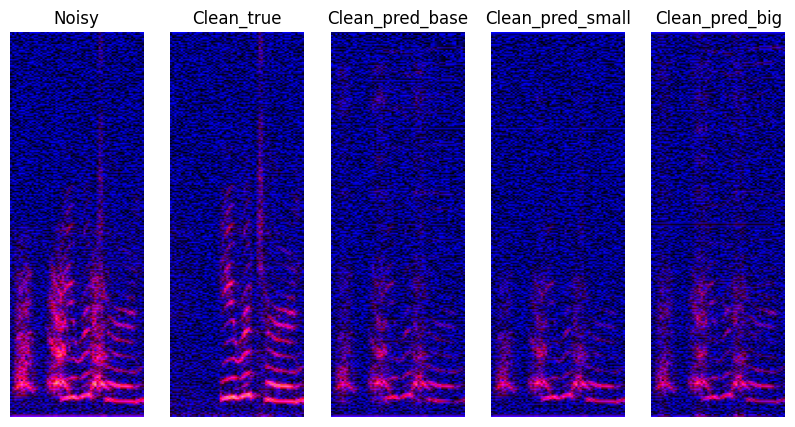

```python
%matplotlib inline
from scipy.io.wavfile import write
n = 2
rate, audioy = wavfile.read("WavesFromSpecs/y_test/83-11691-0035.wav")
rate, audiox = wavfile.read("WavesFromSpecs/test/83-11691-0035.wav")
audiox = audiox[:16000]
audioy = audioy[:16000]

predbase = un_1d_base.predict([tf.expand_dims(audiox, axis=0)])
predsmall = un_1d_small.predict([tf.expand_dims(audiox, axis=0)])
predbig = un_1d_big.predict([tf.expand_dims(audiox, axis=0)])
# pred = un_1d_small.predict(audiox)
fig, axes = plt.subplots(1, 5, figsize = (10,5))
# noisy = generateSpectrogramForWave(np.array(X))
# clean = generateSpectrogramForWave(np.array(y))
noisy = generateSpectrogramForWave(audiox)
clean = generateSpectrogramForWave(audioy)

predbasewav = np.array(tf.squeeze(predbase[0]))
predsmallwav = np.array(tf.squeeze(predsmall[0]))
predbigwav = np.array(tf.squeeze(predbig[0]))

predbase = generateSpectrogramForWave(predbasewav)
predsmall = generateSpectrogramForWave(predsmallwav)
predbig = generateSpectrogramForWave(predbigwav)

axes[0].imshow(noisy, aspect='auto')
axes[0].set_axis_off()
axes[0].set_title('Noisy')
axes[1].imshow(clean, aspect = 'auto')
axes[1].set_axis_off()
axes[1].set_title('Clean_true')
axes[2].imshow(predbase, aspect = 'auto')
axes[2].set_axis_off()
axes[2].set_title('Clean_pred_base')
axes[3].imshow(predsmall, aspect = 'auto')
axes[3].set_axis_off()
axes[3].set_title('Clean_pred_small')
axes[4].imshow(predbig, aspect = 'auto')
axes[4].set_axis_off()
axes[4].set_title('Clean_pred_big')
plt.show()
write("WavOut/predBase.wav", 16000, predbasewav)
write("WavOut/predSmall.wav", 16000, predsmallwav)
write("WavOut/predBig.wav", 16000, predbigwav)
write("WavOut/prednoisy.wav", 16000, audiox)
write("WavOut/predclean.wav", 16000, audioy)
```

# Create 0.5X Kernel/Window Model

```python
# Define the model
rate = 16000
file_length = rate
batch_size = 16
filterX = 1
windowX = 0.5
# input_size1d = (1,16128)
input_size1d = (rate,1)
inp = Input(shape=(input_size1d))
c1 = Conv1D(2*filterX, int(32*windowX), 2, 'same', activation='relu')(inp)
c2 = Conv1D(4*filterX, int(32*windowX), 2, 'same', activation='relu')(c1)
c3 = Conv1D(8*filterX, int(32*windowX), 2, 'same', activation='relu')(c2)
c4 = Conv1D(16*filterX, int(32*windowX), 2, 'same', activation='relu')(c3)
c5 = Conv1D(32*filterX, int(32*windowX), 2, 'same', activation='relu')(c4)

dc1 = Conv1DTranspose(32*filterX, int(32*windowX), 1, padding='same')(c5)
conc = Concatenate()([c5, dc1])
dc2 = Conv1DTranspose(16*filterX, int(32*windowX), 2, padding='same')(conc)
conc = Concatenate()([c4, dc2])
dc3 = Conv1DTranspose(8*filterX, int(32*windowX), 2, padding='same')(conc)
conc = Concatenate()([c3, dc3])
dc4 = Conv1DTranspose(4*filterX, int(32*windowX), 2, padding='same')(conc)
conc = Concatenate()([c2, dc4])
dc5 = Conv1DTranspose(2*filterX, int(32*windowX), 2, padding='same')(conc)
conc = Concatenate()([c1, dc5])
dc6 = Conv1DTranspose(1, int(32*windowX), 2, padding='same')(conc)
conc = Concatenate()([inp, dc6])
dc7 = Conv1DTranspose(1, int(32*windowX), 1, padding='same', activation='linear')(conc)

un_1d_halfwin = tf.keras.models.Model(inp, dc7)
# un_1d_base.compile(optimizer=tf.keras.optimizers.Adam(0.002),loss='mse',metrics=['mae','accuracy']
un_1d_halfwin.compile(optimizer=tf.keras.optimizers.Adam(0.001),loss='mse',metrics=['mae','accuracy'])
un_1d_halfwin.summary()
```

```
2024-05-09 00:05:48.179867: I tensorflow/core/common_runtime/gpu/gpu_device.cc:1638] Created device /job:localhost/replica:0/task:0/device:GPU:0 with 13797 MB memory:  -> device: 0, name: Tesla T4, pci bus id: 0000:61:00.0, compute capability: 7.5
```

```
Model: "model"
__________________________________________________________________________________________________
 Layer (type)                   Output Shape         Param #     Connected to
==================================================================================================
 input_1 (InputLayer)           [(None, 16000, 1)]   0           []

 conv1d (Conv1D)                (None, 8000, 2)      34          ['input_1[0][0]']

 conv1d_1 (Conv1D)              (None, 4000, 4)      132         ['conv1d[0][0]']

 conv1d_2 (Conv1D)              (None, 2000, 8)      520         ['conv1d_1[0][0]']

 conv1d_3 (Conv1D)              (None, 1000, 16)     2064        ['conv1d_2[0][0]']

 conv1d_4 (Conv1D)              (None, 500, 32)      8224        ['conv1d_3[0][0]']

 conv1d_transpose (Conv1DTransp  (None, 500, 32)     16416       ['conv1d_4[0][0]']
 ose)

 concatenate (Concatenate)      (None, 500, 64)      0           ['conv1d_4[0][0]',
                                                                  'conv1d_transpose[0][0]']

 conv1d_transpose_1 (Conv1DTran  (None, 1000, 16)    16400       ['concatenate[0][0]']
 spose)

 concatenate_1 (Concatenate)    (None, 1000, 32)     0           ['conv1d_3[0][0]',
                                                                  'conv1d_transpose_1[0][0]']

 conv1d_transpose_2 (Conv1DTran  (None, 2000, 8)     4104        ['concatenate_1[0][0]']
 spose)

 concatenate_2 (Concatenate)    (None, 2000, 16)     0           ['conv1d_2[0][0]',
                                                                  'conv1d_transpose_2[0][0]']

 conv1d_transpose_3 (Conv1DTran  (None, 4000, 4)     1028        ['concatenate_2[0][0]']
 spose)

 concatenate_3 (Concatenate)    (None, 4000, 8)      0           ['conv1d_1[0][0]',
                                                                  'conv1d_transpose_3[0][0]']

 conv1d_transpose_4 (Conv1DTran  (None, 8000, 2)     258         ['concatenate_3[0][0]']
 spose)

 concatenate_4 (Concatenate)    (None, 8000, 4)      0           ['conv1d[0][0]',
                                                                  'conv1d_transpose_4[0][0]']

 conv1d_transpose_5 (Conv1DTran  (None, 16000, 1)    65          ['concatenate_4[0][0]']
 spose)

 concatenate_5 (Concatenate)    (None, 16000, 2)     0           ['input_1[0][0]',
                                                                  'conv1d_transpose_5[0][0]']

 conv1d_transpose_6 (Conv1DTran  (None, 16000, 1)    33          ['concatenate_5[0][0]']
 spose)

==================================================================================================
Total params: 49,278
Trainable params: 49,278
Non-trainable params: 0
__________________________________________________________________________________________________
```

# Train the 0.5 Kernel/Window Model

Train the model three times saving each one so we can average the metrics. Due to memory contraints this model may be commented out for the final print but it was used to generate the 0.5X Kernel/Window models.

```python
for i in range(3):
    # Define the model
    file_length = rate
    batch_size = 16
    filterX = 1
    windowX = 0.5
    # input_size1d = (1,16128)
    input_size1d = (rate,1)
    inp = Input(shape=(input_size1d))
    c1 = Conv1D(2*filterX, int(32*windowX), 2, 'same', activation='relu')(inp)
    c2 = Conv1D(4*filterX, int(32*windowX), 2, 'same', activation='relu')(c1)
    c3 = Conv1D(8*filterX, int(32*windowX), 2, 'same', activation='relu')(c2)
    c4 = Conv1D(16*filterX, int(32*windowX), 2, 'same', activation='relu')(c3)
    c5 = Conv1D(32*filterX, int(32*windowX), 2, 'same', activation='relu')(c4)

    dc1 = Conv1DTranspose(32*filterX, int(32*windowX), 1, padding='same')(c5)
    conc = Concatenate()([c5, dc1])
    dc2 = Conv1DTranspose(16*filterX, int(32*windowX), 2, padding='same')(conc)
    conc = Concatenate()([c4, dc2])
    dc3 = Conv1DTranspose(8*filterX, int(32*windowX), 2, padding='same')(conc)
    conc = Concatenate()([c3, dc3])
    dc4 = Conv1DTranspose(4*filterX, int(32*windowX), 2, padding='same')(conc)
    conc = Concatenate()([c2, dc4])
    dc5 = Conv1DTranspose(2*filterX, int(32*windowX), 2, padding='same')(conc)
    conc = Concatenate()([c1, dc5])
    dc6 = Conv1DTranspose(1, int(32*windowX), 2, padding='same')(conc)
    conc = Concatenate()([inp, dc6])
    dc7 = Conv1DTranspose(1, int(32*windowX), 1, padding='same', activation='linear')(conc)

    un_1d_halfwin = tf.keras.models.Model(inp, dc7)
    # un_1d_base.compile(optimizer=tf.keras.optimizers.Adam(0.002),loss='mse',metrics=['mae','accuracy']
    un_1d_halfwin.compile(optimizer=tf.keras.optimizers.Adam(0.001),loss='mse',metrics=['mae','accuracy'])
    historyhalf = un_1d_halfwin.fit(train_dataset,epochs=20)
    un_1d_halfwin.save(f"un_1d_halfwin{i}.keras")
    K.clear_session()
```

# Create and Train 2X Kernel Model

```python
for i in range(3):
    # Define the model
    file_length = rate
    batch_size = 16
    filterX = 1
    windowX = 2
    # input_size1d = (1,16128)
    input_size1d = (rate,1)
    inp = Input(shape=(input_size1d))
    c1 = Conv1D(2*filterX, int(32*windowX), 2, 'same', activation='relu')(inp)
    c2 = Conv1D(4*filterX, int(32*windowX), 2, 'same', activation='relu')(c1)
    c3 = Conv1D(8*filterX, int(32*windowX), 2, 'same', activation='relu')(c2)
    c4 = Conv1D(16*filterX, int(32*windowX), 2, 'same', activation='relu')(c3)
    c5 = Conv1D(32*filterX, int(32*windowX), 2, 'same', activation='relu')(c4)

    dc1 = Conv1DTranspose(32*filterX, int(32*windowX), 1, padding='same')(c5)
    conc = Concatenate()([c5, dc1])
    dc2 = Conv1DTranspose(16*filterX, int(32*windowX), 2, padding='same')(conc)
    conc = Concatenate()([c4, dc2])
    dc3 = Conv1DTranspose(8*filterX, int(32*windowX), 2, padding='same')(conc)
    conc = Concatenate()([c3, dc3])
    dc4 = Conv1DTranspose(4*filterX, int(32*windowX), 2, padding='same')(conc)
    conc = Concatenate()([c2, dc4])
    dc5 = Conv1DTranspose(2*filterX, int(32*windowX), 2, padding='same')(conc)
    conc = Concatenate()([c1, dc5])
    dc6 = Conv1DTranspose(1, int(32*windowX), 2, padding='same')(conc)
    conc = Concatenate()([inp, dc6])
    dc7 = Conv1DTranspose(1, int(32*windowX), 1, padding='same', activation='linear')(conc)

    un_1d_doublewin = tf.keras.models.Model(inp, dc7)
    # un_1d_base.compile(optimizer=tf.keras.optimizers.Adam(0.002),loss='mse',metrics=['mae','accuracy']
    un_1d_doublewin.compile(optimizer=tf.keras.optimizers.Adam(0.001),loss='mse',metrics=['mae','accuracy'])
    historydouble = un_1d_doublewin.fit(train_dataset,epochs=20)
    un_1d_doublewin.save(f"un_1d_doublewin{i}.keras")
    K.clear_session()
```

# Create and Train 5X Kernel Model

```python
for i in range(3):
    # Define the model
    file_length = rate
    batch_size = 16
    filterX = 1
    windowX = 5
    # input_size1d = (1,16128)
    input_size1d = (rate,1)
    inp = Input(shape=(input_size1d))
    c1 = Conv1D(2*filterX, int(32*windowX), 2, 'same', activation='relu')(inp)
    c2 = Conv1D(4*filterX, int(32*windowX), 2, 'same', activation='relu')(c1)
    c3 = Conv1D(8*filterX, int(32*windowX), 2, 'same', activation='relu')(c2)
    c4 = Conv1D(16*filterX, int(32*windowX), 2, 'same', activation='relu')(c3)
    c5 = Conv1D(32*filterX, int(32*windowX), 2, 'same', activation='relu')(c4)

    dc1 = Conv1DTranspose(32*filterX, int(32*windowX), 1, padding='same')(c5)
    conc = Concatenate()([c5, dc1])
    dc2 = Conv1DTranspose(16*filterX, int(32*windowX), 2, padding='same')(conc)
    conc = Concatenate()([c4, dc2])
    dc3 = Conv1DTranspose(8*filterX, int(32*windowX), 2, padding='same')(conc)
    conc = Concatenate()([c3, dc3])
    dc4 = Conv1DTranspose(4*filterX, int(32*windowX), 2, padding='same')(conc)
    conc = Concatenate()([c2, dc4])
    dc5 = Conv1DTranspose(2*filterX, int(32*windowX), 2, padding='same')(conc)
    conc = Concatenate()([c1, dc5])
    dc6 = Conv1DTranspose(1, int(32*windowX), 2, padding='same')(conc)
    conc = Concatenate()([inp, dc6])
    dc7 = Conv1DTranspose(1, int(32*windowX), 1, padding='same', activation='linear')(conc)

    un_1d_5win = tf.keras.models.Model(inp, dc7)
    # un_1d_base.compile(optimizer=tf.keras.optimizers.Adam(0.002),loss='mse',metrics=['mae','accuracy']
    un_1d_5win.compile(optimizer=tf.keras.optimizers.Adam(0.001),loss='mse',metrics=['mae','accuracy'])
    history5 = un_1d_5win.fit(train_dataset,epochs=20)
    un_1d_5win.save(f"un_1d_5win{i}.keras")
    K.clear_session()
```

# Create and Test a Model Over 5 Epochs to Support that the Models are not Overfitting

5 epochs

```python
for i in range(3):
    # Define the model
    file_length = rate
    batch_size = 16
    filterX = 1
    windowX = 1
    # input_size1d = (1,16128)
    input_size1d = (rate,1)
    inp = Input(shape=(input_size1d))
    c1 = Conv1D(2*filterX, int(32*windowX), 2, 'same', activation='relu')(inp)
    c2 = Conv1D(4*filterX, int(32*windowX), 2, 'same', activation='relu')(c1)
    c3 = Conv1D(8*filterX, int(32*windowX), 2, 'same', activation='relu')(c2)
    c4 = Conv1D(16*filterX, int(32*windowX), 2, 'same', activation='relu')(c3)
    c5 = Conv1D(32*filterX, int(32*windowX), 2, 'same', activation='relu')(c4)

    dc1 = Conv1DTranspose(32*filterX, int(32*windowX), 1, padding='same')(c5)
    conc = Concatenate()([c5, dc1])
    dc2 = Conv1DTranspose(16*filterX, int(32*windowX), 2, padding='same')(conc)
    conc = Concatenate()([c4, dc2])
    dc3 = Conv1DTranspose(8*filterX, int(32*windowX), 2, padding='same')(conc)
    conc = Concatenate()([c3, dc3])
    dc4 = Conv1DTranspose(4*filterX, int(32*windowX), 2, padding='same')(conc)
    conc = Concatenate()([c2, dc4])
    dc5 = Conv1DTranspose(2*filterX, int(32*windowX), 2, padding='same')(conc)
    conc = Concatenate()([c1, dc5])
    dc6 = Conv1DTranspose(1, int(32*windowX), 2, padding='same')(conc)
    conc = Concatenate()([inp, dc6])
    dc7 = Conv1DTranspose(1, int(32*windowX), 1, padding='same', activation='linear')(conc)

    un_1d_5e = tf.keras.models.Model(inp, dc7)
    # un_1d_base.compile(optimizer=tf.keras.optimizers.Adam(0.002),loss='mse',metrics=['mae','accuracy']
    un_1d_5e.compile(optimizer=tf.keras.optimizers.Adam(0.001),loss='mse',metrics=['mae','accuracy'])
    history5e = un_1d_5e.fit(train_dataset,epochs=5)
    un_1d_5e.save(f"un_1d_5epoch{i}.keras")
    K.clear_session()
```

# Create and Train a Model with AdaGrad Optimizer

Recreate the Base model with an AdaGrad optimizer and 2.5 times as many epochs as the AdaGrad has shown in other projects We've worked on to train well but take significantly longer than other solvers such as Adam.

```python
for i in range(3):
    # Define the model
    file_length = rate
    batch_size = 16
    filterX = 1
    windowX = 1
    # input_size1d = (1,16128)
    input_size1d = (rate,1)
    inp = Input(shape=(input_size1d))
    c1 = Conv1D(2*filterX, int(32*windowX), 2, 'same', activation='relu')(inp)
    c2 = Conv1D(4*filterX, int(32*windowX), 2, 'same', activation='relu')(c1)
    c3 = Conv1D(8*filterX, int(32*windowX), 2, 'same', activation='relu')(c2)
    c4 = Conv1D(16*filterX, int(32*windowX), 2, 'same', activation='relu')(c3)
    c5 = Conv1D(32*filterX, int(32*windowX), 2, 'same', activation='relu')(c4)

    dc1 = Conv1DTranspose(32*filterX, int(32*windowX), 1, padding='same')(c5)
    conc = Concatenate()([c5, dc1])
    dc2 = Conv1DTranspose(16*filterX, int(32*windowX), 2, padding='same')(conc)
    conc = Concatenate()([c4, dc2])
    dc3 = Conv1DTranspose(8*filterX, int(32*windowX), 2, padding='same')(conc)
    conc = Concatenate()([c3, dc3])
    dc4 = Conv1DTranspose(4*filterX, int(32*windowX), 2, padding='same')(conc)
    conc = Concatenate()([c2, dc4])
    dc5 = Conv1DTranspose(2*filterX, int(32*windowX), 2, padding='same')(conc)
    conc = Concatenate()([c1, dc5])
    dc6 = Conv1DTranspose(1, int(32*windowX), 2, padding='same')(conc)
    conc = Concatenate()([inp, dc6])
    dc7 = Conv1DTranspose(1, int(32*windowX), 1, padding='same', activation='linear')(conc)

    un_1d_ada = tf.keras.models.Model(inp, dc7)
    # un_1d_base.compile(optimizer=tf.keras.optimizers.Adam(0.002),loss='mse',metrics=['mae','accuracy']
    un_1d_ada.compile(optimizer=tf.keras.optimizers.Adagrad(),loss='mse',metrics=['mae','accuracy'])
    historyada = un_1d_ada.fit(train_dataset,epochs=50)
    un_1d_ada.save(f"un_1d_ada{i}.keras")
    K.clear_session()
```

Analysis of the models and their performance can be found in the TrainingFinalSubmission.ipynb